# DATA 607 assignment 2A:SQL and R

Lionel jr. desroses

2026-09-05

## Introduction

The purpose of this project is to collect and analyze movie ratings using a PostgreSQL database and R. Six recent movies were selected. Six participants were asked to rate each movie they had seen on a scale from 1 to 5, where 1 represents “strongly dislike” and 5 represents “strongly like.” The collected ratings were stored in a normalized PostgreSQL database consisting of three tables: users, movies, and ratings. This design demonstrates the use of primary keys, foreign keys, and many-to-many relationships. After the data was stored in PostgreSQL, it was imported into R for analysis. Using packages such as dplyr and ggplot2, summary statistics and visualizations were created to identify trends in movie ratings and movie popularity. Missing ratings were treated as movies that participants had not seen and were tracked separately during the analysis.

```r
con <- dbConnect(
  RPostgres::Postgres(),
 dbname = "LDATA607",
 host = "localhost",
 port = 5433,
 user = "postgres",

)
```

## postgreSQL database creation and data population

The database for this project was created manually in PostgreSQL. Three tables were created: users, movies, and ratings. The users table stores participant information, the movies table stores movie information, and the ratings table stores individual movie ratings.Data was collected directly from six participants and entered into the database manually. The ratings table links users and movies through foreign key relationships, allowing each user to rate multiple movies and each movie to receive ratings from multiple users.

```sql
--create table users(users_id Serial PRIMARY KEY, users_name VARCHAR(50)NOT NULL);

--create table movies (movies_id serial primary key, movie_title varchar(100)not null, genres varchar(50), release_year integer);

--create table ratings (rating_id serial primary key, user_id integer not null,movies_id integer not null, rating integer check (rating between 1 and 5), constraint fk_user FOREIGN key(user_id)references users(users_id),constraint fk_movie FOREIGN key(movies_id)references movies(movies_id))

--select * from users;

--insert into movies (movies_id, movie_title,genres,release_year)values(6,'Minions & Monsters','Comedy/Adventure',2026);

--select * from movies;

--insert into users (users_name) VALUES ('MIKE'),('paul'),('zege'),('aly'),('church');

--select * from ratings;

--INSERT INTO ratings (user_id, movies_id, rating)VALUES(1,1,5),(1,2,4),(1,3,5), (2,1,4) ,(2,2,5),(2,5,3),(3,1,5),(3,4,4),(3,6,5),(4,1,5),(4,3,1),(5,1,5),(5,6,5),(6,3,5);

--INSERT INTO ratings (user_id, movies_id, rating) VALUES (1,4,NULL),  (1,5,NULL), (1,6,3),(2,3,NULL), (2,4,NULL), (2,6,NULL),(3,2,NULL), (3,5,NULL),(4,2,NULL),(4,4,NULL),(4,5,2), (4,6,NULL), (5,2,NULL), (5,3,3), (5,4,NULL), (5,5,5),(6,1,5),(6,2,NULL),(6,4,NULL),(6,5,4), (6,6,NULL);

--SELECT
  u.users_name,
  m.movie_title,
  r.rating
FROM ratings r
JOIN users u
  ON r.user_id = u.users_id
JOIN movies m
  ON r.movies_id = m.movies_id
ORDER BY u.users_name, m.movie_title;


--select * from ratings;
```

## importing data into R

In this section, the data stored in PostgreSQL is imported into R using the RPostgres package. Separate queries were used to retrieve the users, movies, and ratings tables. The ratings data was joined with the users and movies tables to create a single dataframe for analysis. Missing ratings were converted into a “Not Seen” category to better represent movies that participants had not watched. To improve reproducibility, the final dataframe was exported to a CSV file and included in the GitHub repository.

```r
users_df<-dbGetQuery(con,"select * from users")
users_df
```

```
##   users_id users_name
## 1        1     lionel
## 2        2       MIKE
## 3        3       paul
## 4        4       zege
## 5        5        aly
## 6        6     church
```

```r
movies_df <-dbGetQuery(con,"select * from movies;")
movies_df
```

```
##   movies_id                  movie_title            genres release_year
## 1         1     spider man brand new day  Action/Adventure         2026
## 2         2                  The Odyssey   Action/Fantasy          2026
## 3         3                  Toy Story 5 Comedy/Adventure          2026
## 4         4 The Super Mario Galaxy Movie  Family/Adventure         2026
## 5         5                      Michael     Musical/Music         2026
## 6         6           Minions & Monsters  Comedy/Adventure         2026
```

```r
ratings_df<- dbGetQuery(con,
"SELECT
  u.users_name,
  m.movie_title,
  r.rating
FROM ratings r
JOIN users u
  ON r.user_id = u.users_id
JOIN movies m
  ON r.movies_id = m.movies_id
ORDER BY u.users_name, m.movie_title;")


ratings_df <- ratings_df %>%
 mutate(
  rating_status = ifelse(is.na(rating),
              "Not Seen",
              as.character(rating))
 )

write.csv(
 ratings_df,
 "movie_ratings.csv",
 row.names = FALSE
)

ratings_df
```

```
##    users_name                  movie_title rating rating_status
## 1         aly                      Michael      5             5
## 2         aly                      Michael      5             5
## 3         aly           Minions & Monsters      5             5
## 4         aly     spider man brand new day      5             5
## 5         aly                  The Odyssey     NA      Not Seen
## 6         aly                  The Odyssey     NA      Not Seen
## 7         aly The Super Mario Galaxy Movie     NA      Not Seen
## 8         aly The Super Mario Galaxy Movie     NA      Not Seen
## 9         aly                  Toy Story 5      3             3
## 10        aly                  Toy Story 5      3             3
## 11     church                      Michael      4             4
## 12     church                      Michael      4             4
## 13     church           Minions & Monsters     NA      Not Seen
## 14     church           Minions & Monsters     NA      Not Seen
```

[output cut: 42 more lines]

## Summary Statistic

```r
movie_summary <- ratings_df %>%
 group_by(movie_title) %>%
 summarize(
  avg_rating = mean(rating,na.rm=TRUE),
  num_ratings = n()
 )

movie_summary
```

```
## # A tibble: 6 × 3
##   movie_title                  avg_rating num_ratings
##   <chr>                             <dbl>       <int>
## 1 Michael                            3.57          11
## 2 Minions & Monsters                 4             10
## 3 The Odyssey                        4.5           10
## 4 The Super Mario Galaxy Movie       4             11
## 5 Toy Story 5                        3.4            7
## 6 spider man brand new day           4.86           7
```

```r
not_seen_summary <- ratings_df%>%
  group_by(movie_title) %>%
  summarize(
    not_seen = sum(is.na(rating))
  )
not_seen_summary
```

```
## # A tibble: 6 × 2
##   movie_title                  not_seen
##   <chr>                           <int>
## 1 Michael                             4
## 2 Minions & Monsters                  6
## 3 The Odyssey                         8
## 4 The Super Mario Galaxy Movie       10
## 5 Toy Story 5                         2
## 6 spider man brand new day            0
```

```r
movie_summary_wna <- ratings_df %>%
 group_by(movie_title) %>%
 summarize(
  avg_rating = mean(rating,na.rm=TRUE),
  rating_received = sum(!is.na(rating)),
  num_ratings = n(),
  not_seen = sum(is.na(rating))
 )
movie_summary_wna
```

```
## # A tibble: 6 × 5
##   movie_title                  avg_rating rating_received num_ratings not_seen
##   <chr>                             <dbl>           <int>       <int>    <int>
## 1 Michael                            3.57               7          11        4
## 2 Minions & Monsters                 4                  4          10        6
## 3 The Odyssey                        4.5                2          10        8
## 4 The Super Mario Galaxy Movie       4                  1          11       10
## 5 Toy Story 5                        3.4                5           7        2
## 6 spider man brand new day           4.86               7           7        0
```

## Data Visualizations

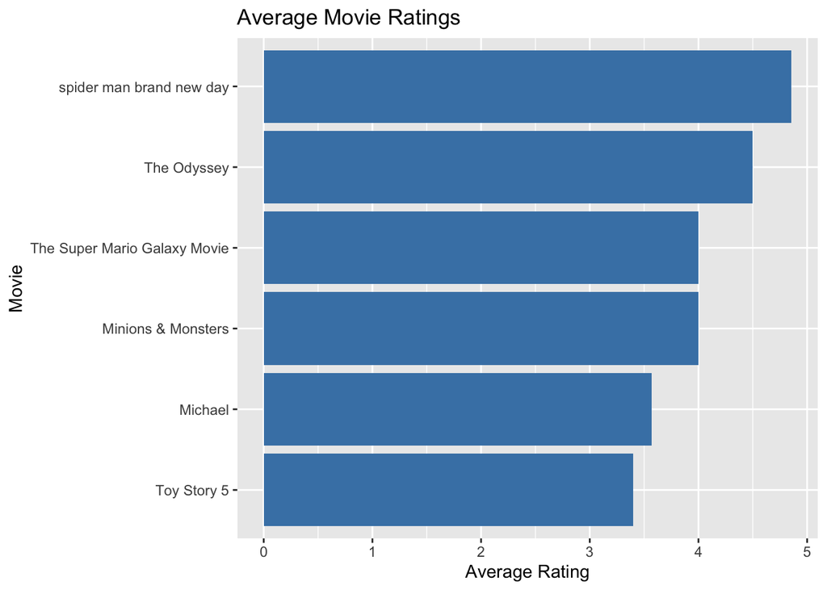

```r
ggplot(movie_summary,
    aes(x = reorder(movie_title, avg_rating),
      y = avg_rating)) +
 geom_col(fill = "steelblue") +
 coord_flip() +
 labs(
  title = "Average Movie Ratings",
  x = "Movie",
  y = "Average Rating"
 )
```

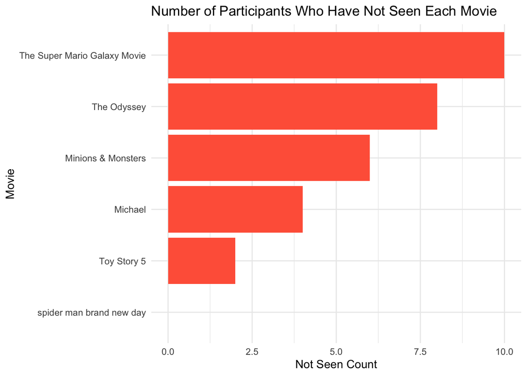

```r
ggplot(movie_summary_wna,
    aes(x = reorder(movie_title, not_seen),
      y = not_seen)) +
 geom_col(fill = "tomato") +
 coord_flip() +
 labs(
  title = "Number of Participants Who Have Not Seen Each Movie",
  x = "Movie",
  y = "Not Seen Count"
 ) +
 theme_minimal()
```

## conclusion

in conclusion, This project demonstrated how PostgreSQL and R can be used together to collect, store, analyze, and visualize data. A normalized database structure was created using separate users, movies, and ratings tables. The data was then imported into R, where summary statistics and visualizations were generated to evaluate movie ratings and identify viewing trends among participants. One challenge addressed during the project was handling missing ratings. Movies that participants had not seen were stored as NULL values in PostgreSQL and tracked as “Not Seen” responses in R. This approach allowed missing data to be incorporated into the analysis without affecting average rating calculations.

```r
dbDisconnect(con)
```